### cross-validation and classification using the caret package

```
library(caret)
library(C50)
library(plyr)
library(nnet)
library(kernlab)
library(klaR)
library(randomForest)
library(ggplot2)
library(gridExtra)

caret：整合分類與迴歸模型的強大訓練框架
C50, plyr：載入 C5.0 Decision Tree 使用
nnet：載入 Neural Networks 使用
kernlab：載入 SVM with Radial 使用
klaR：載入 Naive Bayes 使用
randomForest：載入 Random Forest 使用
ggplot2：繪圖及空間可視化
gridExtra：繪圖排列功能套件
```

分類 (classification) 是 supervised learning 常見的一種 task，藉由 features 來預測已知的類別 (class)，廣泛應用於機器學習。本次使用的資料集繼續延用 k-means cluster analysis of scotch whiskies 所產出的 output，目的是希望透過威士忌風味特徵(features)，了解這6種演算模型在此次預測類別(class)中的表現，這裡的類別是指群集編號(Groups)。資料一樣只有86筆，13個變數欄位，包括威士忌風味(1至12欄:Body, Sweetness, Smoky, Medicinal, Tobacco, Honey, Spicy, Winey, Nutty, Malty, Fruity, Floral)及群集編號(Groups)

```
## 'data.frame':    86 obs. of  13 variables:
##  $ Body     : int  2 3 1 4 2 2 0 2 2 2 ...
##  $ Sweetness: int  2 3 3 1 2 3 2 3 2 3 ...
##  $ Smoky    : int  2 1 2 4 2 1 0 1 1 2 ...
##  $ Medicinal: int  0 0 0 4 0 1 0 0 0 1 ...
##  $ Tobacco  : int  0 0 0 0 0 0 0 0 0 0 ...
##  $ Honey    : int  2 4 2 0 1 1 1 2 1 0 ...
##  $ Spicy    : int  1 3 0 2 1 1 1 1 0 2 ...
##  $ Winey    : int  2 2 0 0 1 1 0 2 0 0 ...
##  $ Nutty    : int  2 2 2 1 2 0 2 2 2 2 ...
##  $ Malty    : int  2 3 2 2 3 1 2 2 2 1 ...
##  $ Fruity   : int  2 3 3 1 1 1 3 2 2 2 ...
##  $ Floral   : int  2 2 2 0 1 2 3 1 2 1 ...
##  $ Groups   : Factor w/ 3 levels "1","2","3": 2 2 1 3 1 1 1 2 1 1 ...
```

為了確保分類的信賴程度、降低 overfitting 的發生，交叉驗證 (cross-validation, CV) 是必要的。常見的形式有 leave-one-out CV 和 k-fold CV 等，使用 caret 套件中的 trainControl() 即可設定，10-fold CV 是業界常用的標準，由於本案例的資料量很小，這裡使用了 10-fold CV 重複5次的做法…

```r
# set CV
ctrl <- trainControl(method = "repeatedcv", number = 10, repeats = 5)
```

caret 套件能透過參數的組合來建立模型，此函式依據傳入的模型結果，找出參數當中的最佳解。accuracy 和 kappa 值常用來評估分類的 performance，以下設定 kappa 值最大時為最佳解

```r
# get best result
getBest <- function(md)
{
  df <- md$results
  index <- best(df, metric = "Kappa", maximize = TRUE)
  best.df <- df[index,]
  return(best.df)
}
```

caret 套件 [Available Models](http://topepo.github.io/caret/available-models.html) 相當多，只要在 method 設定對應值即可載入。以下的做法將先使用預設參數來建立 model，觀察此 model 最佳解的值及參數，做為後續 tuning process 的依據，接下來的這6種演算模型都採用此策略…

#### **C5.0 Decision Tree**

C5.0 改善了 C4.5 演算法，透過適應增強(adaptive boosting)方式建立許多決策樹，再票選出最佳類別。從執行結果看來，預設的 C5.0 model 最佳解 Kappa = 0.8745444，所使用的參數為 model = rules, winnow = FALSE, trials = 10，一般來說 Kappa 至少要大於 0.6，這個結果已經很不錯，達到 very good agreement 的程度

```r
set.seed(777)
model.C50 <- train(Groups ~ ., data = whisky.feature, metric = "Kappa", trControl = ctrl,
                   method = "C5.0")
getBest(model.C50)
```

|  | model | winnow | trials | Accuracy | Kappa | AccuracySD | KappaSD |
| --- | --- | --- | --- | --- | --- | --- | --- |
| 8 | rules | FALSE | 10 | 0.9319444 | 0.8745444 | 0.0851211 | 0.1566967 |

caret 套件允許各種演算模型設定 tuning 參數，使用 getModelInfo() 可以初步了解 model 所支援的參數類別和說明

```r
# Get Parameter
getModelInfo(model = "C5.0")$C5.0$parameters
```

```
##   parameter     class                 label
## 1    trials   numeric # Boosting Iterations
## 2     model character            Model Type
## 3    winnow   logical                Winnow
```

接下來設定 tuning 參數再重新執行一次，目標是希望 Kappa 值能更好(大於0.8745444)。trials 是增強的迭代次數，手動設定為 1 至 20 ，model 為模型類型(tree or rules)，winnow 為是否使用特徵選取(feature selection)的機制，後二者參數設定還是維持預設值…

```r
set.seed(777)
# Tuning Grids
grid.C50 <- expand.grid(trials = c(1:20), model = "rules", winnow = FALSE)

model.C50 <- train(Groups ~ ., data = whisky.feature, metric = "Kappa", trControl = ctrl,
                   tuneGrid = grid.C50, method = "C5.0")
getBest(model.C50)
```

經過 tuning process，C5.0 得到的最佳 Kappa 值還是0.8745444，從下圖看來 trials = 9, 10 附近的 Kappa 值較大

|  | model | winnow | trials | Accuracy | Kappa | AccuracySD | KappaSD |
| --- | --- | --- | --- | --- | --- | --- | --- |
| 10 | rules | FALSE | 10 | 0.9319444 | 0.8745444 | 0.0851211 | 0.1566967 |

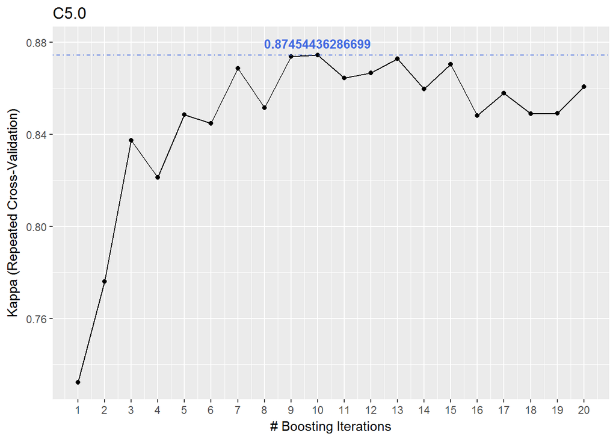

#### **Neural Networks**

第2種演算模型使用神經網絡(Neural Networks)，method 對應值為 nnet，先以預設參數執行…預設的 Neural Networks model 最佳解 Kappa = 0.8082011，所使用的參數為 size = 3, decay = 0.1

```r
set.seed(777)
model.Neural <- train(Groups ~ ., data = whisky.feature, metric = "Kappa", trControl = ctrl,
                      method = "nnet")
getBest(model.Neural)
```

|  | size | decay | Accuracy | Kappa | AccuracySD | KappaSD |
| --- | --- | --- | --- | --- | --- | --- |
| 6 | 3 | 0.1 | 0.8971667 | 0.8082011 | 0.1012465 | 0.1948992 |

nnet 提供2個 tuning 參數，size 是設定 hidden layer 中的單位數(nodes)，size 越大交織出越複雜的網絡(layer 層數如果越多即所謂的 deep learning)，decay 是信號衰變的權重

```r
# Get Parameter
getModelInfo(model = "nnet")$nnet$parameters
```

```
##   parameter   class         label
## 1      size numeric #Hidden Units
## 2     decay numeric  Weight Decay
```

接下來手動設定 tuning 參數，size 設定 1 至 7，衰變權重設定6種，共 42 種組合…

```r
set.seed(777)
# Tuning Grids
grid.Neural <- expand.grid(size = c(1:7), decay = c(0.5, 0.3, 0.1, 0.05, 0.01, 0))

model.Neural <- train(Groups ~ ., data = whisky.feature, metric = "Kappa", trControl = ctrl,
                   tuneGrid = grid.Neural, method = "nnet")
getBest(model.Neural)
```

經過 tuning process，這次得到的最佳 Kappa 值為0.8549912 (大於之前的0.8082011)，所使用的參數設定為 size = 2, decay = 0.1

|  | size | decay | Accuracy | Kappa | AccuracySD | KappaSD |
| --- | --- | --- | --- | --- | --- | --- |
| 10 | 2 | 0.1 | 0.9216111 | 0.8549912 | 0.0903182 | 0.1722453 |

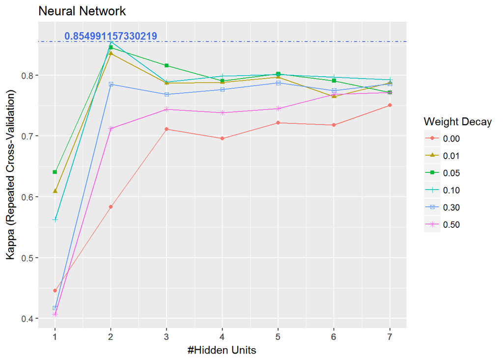

#### **Support Vector Machines (SVM)**

支援向量機(SVM)的目標是找出最大邊界的超平面(hyperplane)，如此一來能精確辨別資料的類別，由於產出的結果缺乏可解釋性，因此和神經網絡一樣都是屬於黑箱(Black Box)方法。SVM 有多種 kernel 參數，這裡使用的 svmRadial 方法屬於徑向核心，預設的 SVM model 最佳解 Kappa = 0.8324079，使用的參數為 sigma = 0.0591834, C = 1

```r
set.seed(777)
model.SVM <- train(Groups ~ ., data = whisky.feature, metric = "Kappa", trControl = ctrl,
                   method = "svmRadial")
getBest(model.SVM)
```

|  | sigma | C | Accuracy | Kappa | AccuracySD | KappaSD |
| --- | --- | --- | --- | --- | --- | --- |
| 3 | 0.0591834 | 1 | 0.9138333 | 0.8324079 | 0.0749874 | 0.1488853 |

svmRadial 提供2個 tuning 參數，sigma 是徑向(radial)核心方法中的一項超參數(hyper-parameters)，C 是 cost 超參數，適用於 SVM 所有核心

```r
# Get Parameter
getModelInfo(model = "svmRadial")$svmRadial$parameters
```

```
##   parameter   class label
## 1     sigma numeric Sigma
## 2         C numeric  Cost
```

手動設定 tuning 參數，sigma 設定0.02, 0.03, … 0.07 試試，C 設定 1.0, 1.5, … 5.0，共 54 種組合…

```r
set.seed(777)
# Tuning Grids
grid.SVM <- expand.grid(sigma = seq(0.02, 0.07, by = 0.01), C = seq(1, 5, length.out = 9))

model.SVM <- train(Groups ~ ., data = whisky.feature, metric = "Kappa", trControl = ctrl,
                      tuneGrid = grid.SVM, method = "svmRadial")
getBest(model.SVM)
```

|  | sigma | C | Accuracy | Kappa | AccuracySD | KappaSD |
| --- | --- | --- | --- | --- | --- | --- |
| 12 | 0.03 | 2 | 0.9449444 | 0.8965109 | 0.0699014 | 0.1309426 |

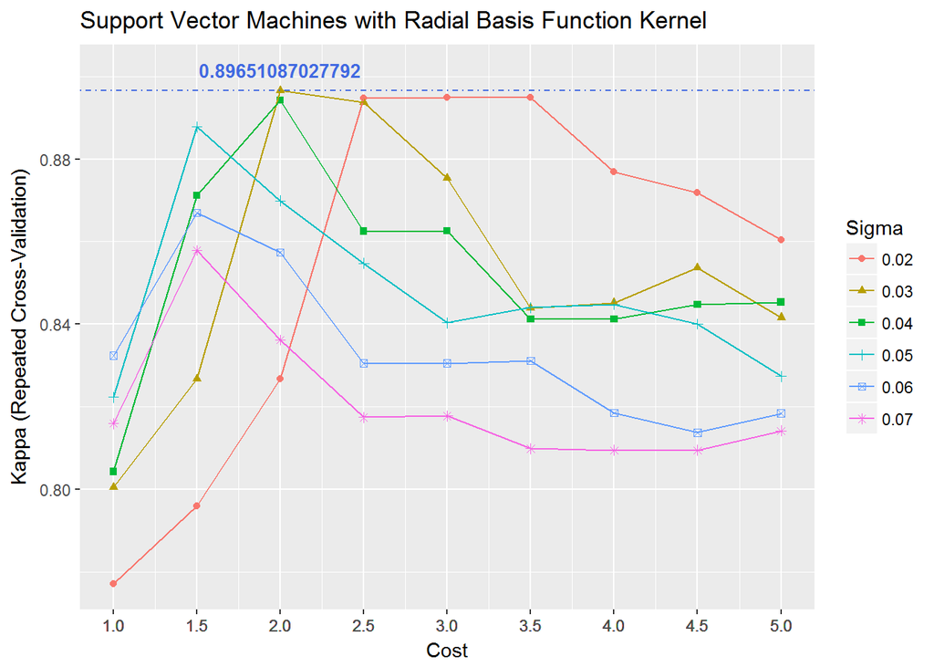

#### **Naive Bayes**

單純貝氏(Naive Bayes)假設各屬性條件獨立，根據貝氏定理的機率方法來進行分類。method 對應值為 nb，預設的 Bayes model 最佳解 Kappa = 0.9030824，使用的參數 usekernel = FALSE, fL = 0, adjust = 1

```r
set.seed(777)
model.Bayes <- train(Groups ~ ., data = whisky.feature, metric = "Kappa", trControl = ctrl,
                     method = "nb")
getBest(model.Bayes)
```

| usekernel | fL | adjust | Accuracy | Kappa | AccuracySD | KappaSD |
| --- | --- | --- | --- | --- | --- | --- |
| FALSE | 0 | 1 | 0.9440278 | 0.9030824 | 0.0861411 | 0.1490858 |

nb 有3個 tuning 參數，fL 是 Laplace 校正值，避免機率相乘結果為零，usekernel 為核心密度估計用，adjust 為密度估計時帶寬(bandwidth)調整的參數

```r
# Get Parameter
getModelInfo(model = "nb")$nb$parameters
```

```
##   parameter   class                label
## 1        fL numeric   Laplace Correction
## 2 usekernel logical    Distribution Type
## 3    adjust numeric Bandwidth Adjustment
```

手動設定 tuning 參數，fL 設定0 至 3，由於沒有要核心密度估計，usekernel 和 adjust 維持預設值

```r
set.seed(777)
# Tuning Grids
grid.Bayes <- expand.grid(fL = c(0:3), usekernel = FALSE, adjust = 1)

model.Bayes <- train(Groups ~ ., data = whisky.feature, metric = "Kappa", trControl = ctrl,
                     tuneGrid = grid.Bayes, method = "nb")
getBest(model.Bayes)
```

經過 tuning process，這次得到的最佳 Kappa 值為0.9030824，即使將 Laplace 值設為1, 2, 3

| fL | usekernel | adjust | Accuracy | Kappa | AccuracySD | KappaSD |
| --- | --- | --- | --- | --- | --- | --- |
| 0 | FALSE | 1 | 0.9440278 | 0.9030824 | 0.0861411 | 0.1490858 |

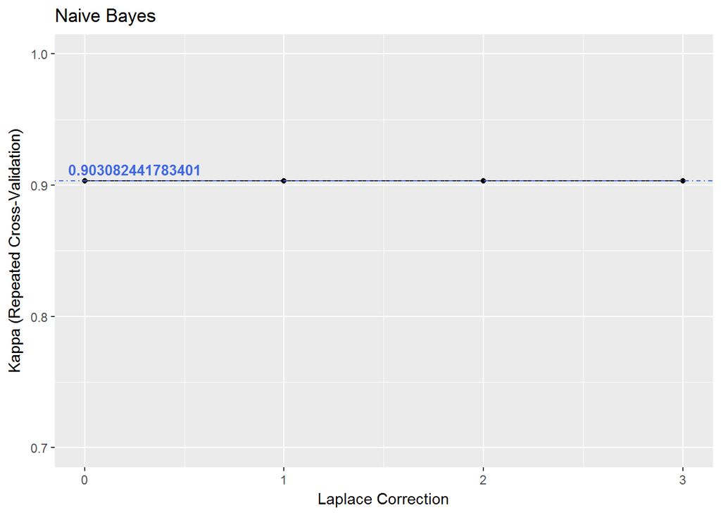

#### **Random Forests**

隨機森林(Random Forests, RF)結合了重抽集成(bootstrap aggregating, 簡稱 bagging)的基本原理，使用隨選特徵(random feature selection)的做法來產生許多決策樹，並利用投票方式組成專家團隊(森林)，因此也稱為 Decision Tree Forests。由於只利用到小部份的隨機特徵，RF 可以處理很大的資料集，避免造成維度詛咒(curse of dimensionality)。預設的 RF model 最佳解 Kappa = 0.8618625，所使用的參數 mtry = 2

```r
set.seed(777)
model.RF <- train(Groups ~ ., data = whisky.feature, metric = "Kappa", trControl = ctrl,
                  method = "rf")
getBest(model.RF)
```

| mtry | Accuracy | Kappa | AccuracySD | KappaSD |
| --- | --- | --- | --- | --- |
| 2 | 0.9291111 | 0.8618625 | 0.0892923 | 0.1808421 |

rf 只有1個 tuning 參數，mtry 是在每次裂解的隨選特徵(預測因子)個數

```r
# Get Parameter
getModelInfo(model = "rf")$rf$parameters
```

```
##   parameter   class                         label
## 1      mtry numeric #Randomly Selected Predictors
```

手動設定 tuning 參數，mtry 設定 1 至 20，查看不同 mtry 值的分類成效…

```r
set.seed(777)
# Tuning Grids
grid.RF <- expand.grid(mtry = c(1:20))

model.RF <- train(Groups ~ ., data = whisky.feature, metric = "Kappa", trControl = ctrl,
                   tuneGrid = grid.RF, method = "rf")
getBest(model.RF)
```

經過 tuning process，得到的最佳 Kappa 值為0.8862256 (大於之前的0.8618625)，所使用的參數 mtry = 4，這個結果與用特徵數開根號的做法相近… sqrt(12) = 3.464102

|  | mtry | Accuracy | Kappa | AccuracySD | KappaSD |
| --- | --- | --- | --- | --- | --- |
| 4 | 4 | 0.9397222 | 0.8862256 | 0.0850915 | 0.1655141 |

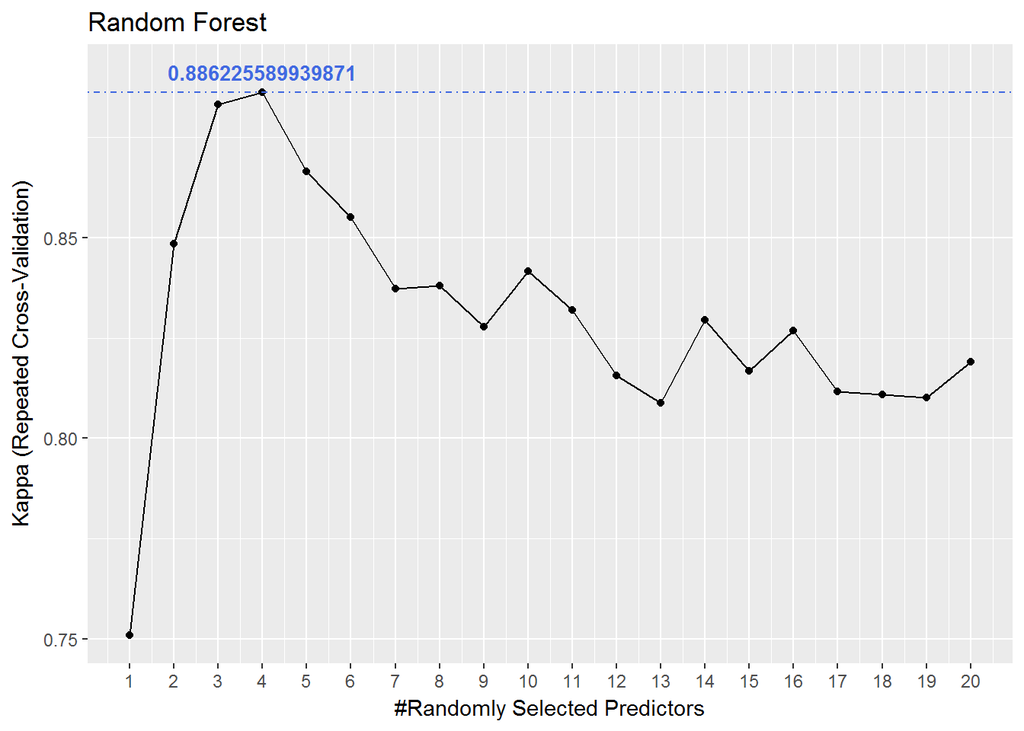

#### **k-Nearest Neighbors (k-NN)**

最後使用懶惰學習法(Lazy Learning) k-NN，一種物以類聚的概念，使用投票表決來制訂所屬的類別，由於簡單又直覺，在分類方法上很常見…預設的 k-NN model 最佳解 Kappa = 0.8893649，所使用的參數 k = 9

```r
set.seed(777)
model.KNN <- train(Groups ~ ., data = whisky.feature, metric = "Kappa", trControl = ctrl,
                   method = "knn")
getBest(model.KNN)
```

|  | k | Accuracy | Kappa | AccuracySD | KappaSD |
| --- | --- | --- | --- | --- | --- |
| 3 | 9 | 0.9426667 | 0.8893649 | 0.0655465 | 0.1253155 |

knn 只有1個 tuning 參數，k 是最鄰近的個數，適當的 k 值設定除了檢測不同 k 值的分類成效，另一個常見的做法是用訓練資料個數的平方根

```r
# Get Parameter
getModelInfo(model = "knn")$knn$parameters
```

```
##   parameter   class      label
## 1         k numeric #Neighbors
```

接下來手動設定 tuning 參數，k 設定 1 至 15，查看不同 k 值的分類成效

```r
set.seed(777)
# Tuning Grids
grid.KNN <- expand.grid(k = c(1:15))

model.KNN <- train(Groups ~ ., data = whisky.feature, metric = "Kappa", trControl = ctrl,
                   tuneGrid = grid.KNN, method = "knn")
getBest(model.KNN)
```

經過 tuning process，維持 k = 9 時 Kappa 值最大，最佳 k 值恰好與訓練資料數的平方根相吻合… sqrt(86 * 0.9) = 8.797727

|  | k | Accuracy | Kappa | AccuracySD | KappaSD |
| --- | --- | --- | --- | --- | --- |
| 9 | 9 | 0.9421667 | 0.8894969 | 0.0676903 | 0.1272385 |

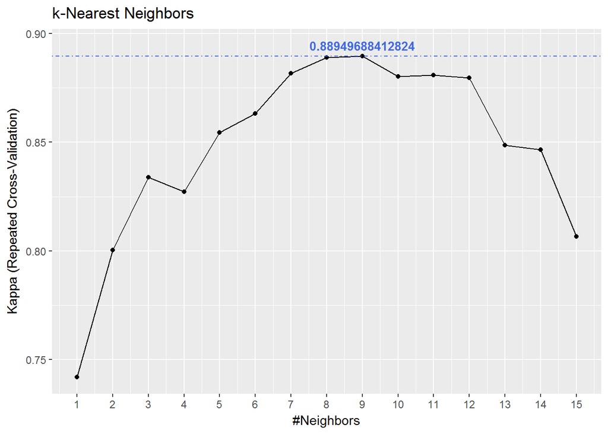

#### **Performance Differences**

在完成6種分類模型後，最後進行分類成效的比較。caret 套件提供了 resamples() 方法，能將各種模型的結果整理及可視化…

```r
resamps <- resamples(
  list(
    C5.0 = model.C50,
    NeuralNetworks = model.Neural,
    SVM = model.SVM,
    NaiveBayes = model.Bayes,
    RandomForests = model.RF,
    KNN = model.KNN
  )
)
```

在準確度(Accuracy)方面，6種分類模型應用在這個資料集的表現上，平均準確度都達到0.92以上，其中以 SVM 的 0.9449 最高，NaiveBayes 的 0.9440 次之…

|  | Min. | 1st Qu. | Median | Mean | 3rd Qu. | Max. | NA’s |
| --- | --- | --- | --- | --- | --- | --- | --- |
| C5.0 | 0.6667 | 0.8750 | 1.0000 | 0.9319 | 1 | 1 | 0 |
| NeuralNetworks | 0.5556 | 0.8750 | 0.8889 | 0.9216 | 1 | 1 | 0 |
| SVM | 0.7778 | 0.8889 | 1.0000 | 0.9449 | 1 | 1 | 0 |
| NaiveBayes | 0.6250 | 0.8889 | 1.0000 | 0.9440 | 1 | 1 | 10 |
| RandomForests | 0.6667 | 0.8889 | 1.0000 | 0.9397 | 1 | 1 | 0 |
| KNN | 0.7500 | 0.8889 | 1.0000 | 0.9422 | 1 | 1 | 0 |

在 Kappa 表現上，各模型的平均值也有達到0.85以上，其中以 NaiveBayes 的 0.9031 最高，SVM 的 0.8965 次之…不過在50次 Resampling 的結果之中，NaiveBayes 都有10次曾出現 NA 的值

|  | Min. | 1st Qu. | Median | Mean | 3rd Qu. | Max. | NA’s |
| --- | --- | --- | --- | --- | --- | --- | --- |
| C5.0 | 0.4286 | 0.7838 | 1.00 | 0.8745 | 1 | 1 | 0 |
| NeuralNetworks | 0.1000 | 0.7524 | 0.82 | 0.8550 | 1 | 1 | 0 |
| SVM | 0.5909 | 0.7857 | 1.00 | 0.8965 | 1 | 1 | 0 |
| NaiveBayes | 0.3333 | 0.8058 | 1.00 | 0.9031 | 1 | 1 | 10 |
| RandomForests | 0.3864 | 0.7955 | 1.00 | 0.8862 | 1 | 1 | 0 |
| KNN | 0.5909 | 0.7857 | 1.00 | 0.8895 | 1 | 1 | 0 |

透過圖示，更容易解讀各項分類成效，總括來說，SVM 和 NaiveBayes 的平均值相近，包辦前2名，不過在 95% 信心水準下，SVM 的信賴區間比較集中

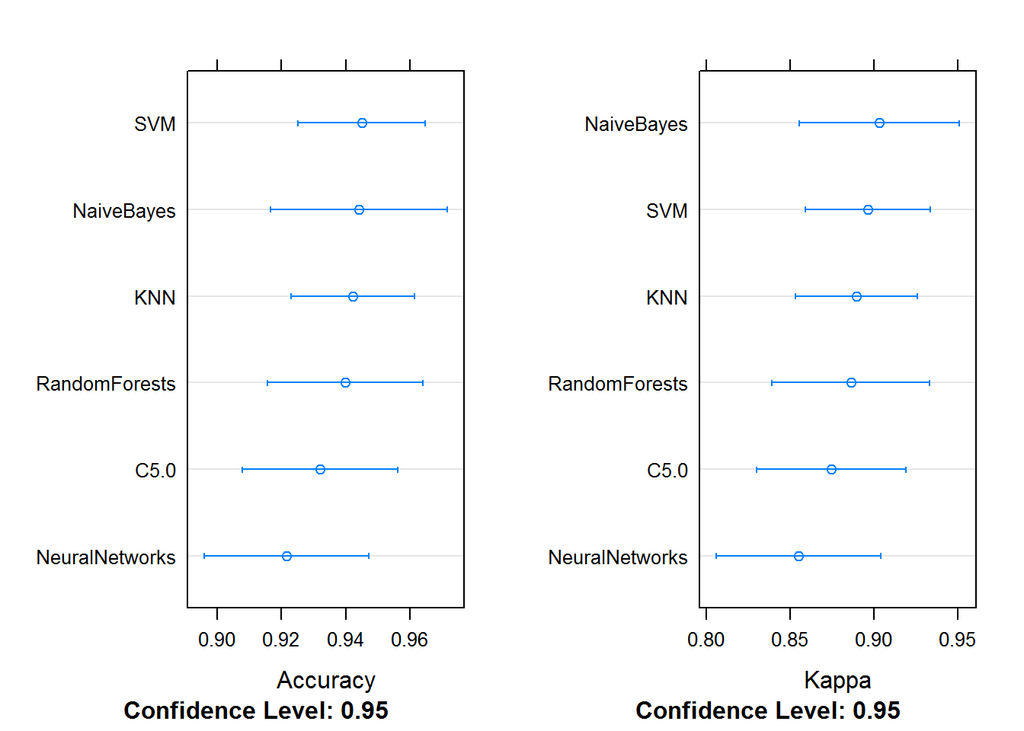

### Lessons Learned:

#### Cross-validation and automated parameter tuning by caret.

#### C5.0 Decision Tree.

#### Support Vector Machines (SVM).

#### k-Nearest Neighbors (k-NN).